# Shapr3D - Data Scientist Homework - Peter Borsos

```python
import pandas as pd
pd.options.display.float_format = "{:.2f}".format
pd.set_option('display.max_rows', 500)
pd.set_option('display.max_columns', 500)
pd.set_option('display.width', 1000)
import datetime
import numpy as np
import plotly.graph_objects as go
from sklearn.model_selection import train_test_split
from sklearn.linear_model import LogisticRegression
from sklearn.linear_model import SGDClassifier
from sklearn.ensemble import AdaBoostClassifier
from sklearn.metrics import fbeta_score, accuracy_score, classification_report, f1_score
import matplotlib.pyplot as pl
import matplotlib.patches as mpatches
from time import time
import plotly.express as px
```

```python
def flag_same_day_multiple_use(row):
    """Purpose of this function to flag an event if it
    occured for the same user within the same day as the previous event"""

    curr_date = row['Date'].strftime("%Y-%m-%d")
    next_date = row['next_date'].strftime("%Y-%m-%d")

    if row['UserId'] == row['next_user'] and curr_date == next_date:
        return 'Same day multiple use'
    else:
        return 'No same day use'

def feature_plot(importances, X_train, y_train):
    """Purpose of this function to visualize the top 5 features
    for the model based on their importance in predicting the outcome"""

    # Display the five most important features
    indices = np.argsort(importances)[::-1]
    columns = X_train.columns.values[indices[:5]]
    values = importances[indices][:5]

    # Creat the plot
    fig = pl.figure(figsize = (9,5))
    pl.title("Normalized Weights for First Five Most Predictive Features", fontsize = 16)
    pl.bar(np.arange(5), values, width = 0.6, align="center", color = '#00A000', \
          label = "Feature Weight")
    pl.bar(np.arange(5) - 0.3, np.cumsum(values), width = 0.2, align = "center", color = '#00A0A0', \
          label = "Cumulative Feature Weight")
    pl.xticks(np.arange(5), columns)
    pl.xlim((-0.5, 4.5))
    pl.ylabel("Weight", fontsize = 12)
    pl.xlabel("Feature", fontsize = 12)

    pl.legend(loc = 'upper center')
    pl.tight_layout()
    pl.show()


def create_usage_flags(row, calc_type):

    """Purpose of this function to generate meaningful flags about the
    data which can be visualized to draw insights
    """

    before_trial = [row['before trial | App - Launch'],
                    row['before trial | Export - Save as - File Exported'],
                    row['before trial | Import - File imported'],
                    row['before trial | Learn - Post onboarding video watched'],
                    row['before trial | Onboarding - Finished'],
                    row['before trial | No same day use'],
                    row['before trial | Same day multiple use']]


    after_trial = [row['during or after trial period | App - Launch'],
                    row['during or after trial period | Export - Save as - File Exported'],
                    row['during or after trial period | Import - File imported'],
                    row['during or after trial period | Learn - Post onboarding video watched'],
                    row['during or after trial period | Onboarding - Finished'],
                    row['during or after trial period | No same day use'],
                    row['during or after trial period | Same day multiple use']]

    if calc_type == 'flag_01':
        # flag users if they've used any features of the app before trial
        if all(t == 0 for t in before_trial):
            return 'no usage before trial'
        else:
            return 'app used before trial'

    if calc_type == 'flag_02':
        # flag users to see when they used more of the product
        if before_trial[0] > after_trial[0]:
            return 'used more before trial'
        elif before_trial[0] == after_trial[0]:
            return 'used same as during trial'
        else:
            return 'used more in trial period'

    if calc_type == 'flag_03':
        # flag users to see when they used consumed more tutorial videos
        #to use the product
        if before_trial[3] > after_trial[3]:
            return 'watched more tutorial before trial'
        elif before_trial[3] == after_trial[3] and all(t > 0 for t in [before_trial[3], after_trial[3]]):
            return 'watched same amount of tutorial before and after'
        elif before_trial[3] == after_trial[3]:
            return "haven't watched any tutorial"
        else:
            return 'watched more tutorial after trial'

    if calc_type == 'flag_04':
        #flag users to see when they used more frequently the product on a daily basis
        if before_trial[6] > after_trial[6]:
            return 'More consecutive daily use before trial'
        elif before_trial[6] == after_trial[6] and all(t > 0 for t in [before_trial[6], after_trial[6]]):
            return 'Same consecutive daily use before and during tutorial'
        elif before_trial[6] == after_trial[6]:
            return "no consecutive daily use"
        else:
            return 'More consecuitve daily use after trial'

def convert_purchase_date(text):
    """Date conversion with null handling for financial data"""
    try:
        return datetime.datetime.strptime(text, '%Y-%m-%d %H:%M:%S')
    except:
        return np.NaN
```

## Data exploration

After joining together the datasets, my inital goal was to understand the data on a high level. Based on the value sets and checking some examples for each users I've made my conclusions about what shall I use for the modelling. (See details at Feature engineering piece) I've exlcluded values where user id was missing, and determined that 66% of the users have not made any purchase after the trial. In addition to the missing users I've excluded the users where a purchase actually happened but more than 14 days from the trial date. For these cases I'm assuming that these are active subscriptions where the trial period happenned long in the past.  
The ratio of each case (subscription of no subscription) should be sufficient for modelling purposes.

```python
#read in data
user_data = pd.read_csv('export-data.tsv', sep='\t')
```

```python
#converting dates
user_data['Date'] = user_data['Date'].apply(lambda text: datetime.datetime.strptime(text, '%m/%d/%Y %H:%M'))
```

```python
user_data.columns
```

```
Index(['EventName', 'Date', 'UserId', 'Country', 'InstallationMediaSource', 'InstallationCampaign', 'Video'], dtype='object')
```

```python
#sorting to see user timeline
user_data.sort_values(['UserId', 'Date'], inplace=True)
# number of users for check
len(user_data['UserId'].drop_duplicates())
```

```
12695
```

```python
#handling null values for users - "mv-9" is just a naming convention for missing values
user_data['UserId'] = user_data['UserId'].fillna('mv-9')

#excluding data points where there's no user id
user_data = user_data[user_data['UserId']!='mv-9'].copy()

#converting user id for easier handling
user_data['UserId'] = user_data['UserId'].astype(int)
```

```python
#reading in financial info
financial_data = pd.read_csv('users_trialed-output.tsv', sep='\t')
financial_data.rename(columns={'user_id' : 'UserId'}, inplace=True)

#type conversion
financial_data['UserId'] = financial_data['UserId'].astype(int)

#joining financial data to telemetry data
user_data = pd.merge(user_data, financial_data, on='UserId', how='left')
```

```python
#check joining
len(user_data[user_data['type'].notnull()]) / len(user_data)
```

```
1.0
```

```python
###GENERATING DUMMY DATA WHILE FINAL DATASET IS RECEIVED
###Generating random data for trial conversion to the USERID-s which are present in the telemetry data
#financial_data = pd.DataFrame(user_data['UserId'].drop_duplicates()).reset_index(drop=True)
#user_time = user_data[['UserId', 'Date', 'EventName']].drop_duplicates()
#filter for app launch events and get first occurance
#user_time = user_time[user_time['EventName']=='App - Launch']
#user_first_occ = user_time.groupby('UserId').head(1)

#separate to buy and no buy, create dates and flags accordingly
#buy = user_first_occ.sample(6981, random_state=25)
#no_buy = user_first_occ[~user_first_occ['UserId'].isin(buy['UserId'])].copy()
#(len(buy) + len(no_buy)) / len(user_first_occ)
#buy['PurchaseType'] = 'Trial conversion'
#no_buy['PurchaseType'] = 'No Trial conversion'

#financial_data = pd.concat([buy, no_buy])
#del(financial_data['EventName'])
#financial_data['purchase_date'] = financial_data.apply(lambda df: df['Date']
#                                                       + datetime.timedelta(days=14) if
#                                                       df['PurchaseType'] == 'Trial conversion'
#                                                      else None, axis=1)
#financial_data = financial_data.sample(frac=1).reset_index(drop=True)
```

```python
#conversion to proper datetype from string
user_data['trial_date'] = user_data['trial_date'].apply(lambda text:
                                                        datetime.datetime.strptime(text, '%Y-%m-%d %H:%M:%S'))

#conversion to proper datetype from string
user_data['purchase_date'] = user_data['purchase_date'].apply(convert_purchase_date)

#difference in days from puchase date and trial date
user_data['days_from_trial_to_purchase'] = user_data.apply(lambda df: 0 if df['purchase_date']
                                                           is np.NaN else (df['purchase_date'] - df['trial_date']).days, axis=1)

user_data['days_from_trial_to_purchase'] = user_data['days_from_trial_to_purchase'].fillna(0)

##filtering out cases where purchase was made more than 14 days from trial date
user_data = user_data[user_data['days_from_trial_to_purchase']<=14].copy()

user_data['purchase_date'] = user_data['purchase_date'].fillna('mv-9')

#creating flag which we want to predict later on
user_data['PurchaseType'] = user_data.apply(lambda df: 'No Trial conversion'
                                            if df['purchase_date'] =='mv-9' else 'Trial conversion', axis=1)
```

```python
#Checking for null ratios and info about each column
user_data.info(verbose=True)
```

```
<class 'pandas.core.frame.DataFrame'>
Int64Index: 233249 entries, 0 to 260826
Data columns (total 12 columns):
EventName                      233249 non-null object
Date                           233249 non-null datetime64[ns]
UserId                         233249 non-null int32
Country                        233223 non-null object
InstallationMediaSource        229391 non-null object
InstallationCampaign           37698 non-null object
Video                          6308 non-null object
trial_date                     233249 non-null datetime64[ns]
purchase_date                  233249 non-null object
type                           233249 non-null object
days_from_trial_to_purchase    233249 non-null float64
PurchaseType                   233249 non-null object
dtypes: datetime64[ns](2), float64(1), int32(1), object(8)
memory usage: 22.2+ MB
```

```python
#checking unique value set for each column
value_set = []
for col in user_data.columns:
    values = list(user_data[col].drop_duplicates())
    number_of_values = len(values)
    value_set.append([col, values, number_of_values])

value_set = pd.DataFrame(value_set, columns=['column_name', 'value_set', 'number_of_values'])
value_set
```

|  | column_name | value_set | number_of_values |
| --- | --- | --- | --- |
| 0 | EventName | [App - Launch, Onboarding - Finished, Import -... | 5 |
| 1 | Date | [2019-11-03 21:39:00, 2019-11-04 19:01:00, 201... | 135894 |
| 2 | UserId | [-2147312148, -2147219809, -2147140411, -21471... | 11890 |
| 3 | Country | [United States, Romania, Italy, United Arab Em... | 152 |
| 4 | InstallationMediaSource | [Organic, Apple Search Ads, nan, googleadwords... | 12 |
| 5 | InstallationCampaign | [nan, EU - Experiment - Broad, App Install - T... | 158 |
| 6 | Video | [nan, Bracket mount, Triangle cap] | 3 |
| 7 | trial_date | [2019-11-03 18:48:31, 2019-07-09 22:13:29, 201... | 11937 |
| 8 | purchase_date | [mv-9, 2019-07-24 04:31:16, 2019-09-28 03:35:0... | 4046 |
| 9 | type | [yearly, monthly] | 2 |
| 10 | days_from_trial_to_purchase | [0.0, 14.0, 13.0, 6.0, 5.0, 12.0, 8.0, 1.0, 10... | 13 |
| 11 | PurchaseType | [No Trial conversion, Trial conversion] | 2 |

```python
#handling missing values for whole data
user_data.fillna('mv-9', inplace=True)
```

```python
#checking user and event unique combiations
user_data[['UserId', 'EventName']].drop_duplicates().sort_values('UserId').head()
```

|  | UserId | EventName |
| --- | --- | --- |
| 0 | -2147312148 | App - Launch |
| 2 | -2147219809 | App - Launch |
| 3 | -2147219809 | Onboarding - Finished |
| 5 | -2147219809 | Import - File imported |
| 12 | -2147219809 | Export - Save as - File Exported |

```python
#check most frequent "sequences" of events
```

```python
sequences = user_data[['UserId', 'EventName']].drop_duplicates().groupby('UserId')['EventName'].apply(' , '.join).reset_index()
sequences['value'] = 1
sequence_count = (sequences[['EventName', 'value']]
                  .groupby('EventName')
                  .sum()
                  .reset_index()
                  .sort_values('value', ascending=False))
sequence_count.head()
```

|  | EventName | value |
| --- | --- | --- |
| 0 | App - Launch | 2523 |
| 44 | App - Launch , Onboarding - Finished | 1028 |
| 1 | App - Launch , Export - Save as - File Exported | 747 |
| 14 | App - Launch , Import - File imported | 579 |
| 119 | Learn - Post onboarding video watched , App - ... | 476 |

```python
sequence_count.to_excel('sequence_check.xlsx', index=False, encoding='utf-8')
```

```python
user_data.columns
```

```
Index(['EventName', 'Date', 'UserId', 'Country', 'InstallationMediaSource', 'InstallationCampaign', 'Video', 'trial_date', 'purchase_date', 'type', 'days_from_trial_to_purchase', 'PurchaseType'], dtype='object')
```

```python
#assigning value to events for easire aggregation
user_data['value'] = 1
```

```python
#checking the ratio of users whom not converted during the trial period
user_pivot = user_data.pivot_table('value', 'UserId', 'PurchaseType', aggfunc='sum')
user_pivot.reset_index(inplace=True)


len(user_pivot[user_pivot['Trial conversion'].isnull()]) / len(user_pivot)
```

```
0.6598822539949537
```

```python
#generating count of event types for user
user_pivot = user_data.pivot_table('value', 'UserId', 'EventName', aggfunc='sum')
user_pivot.reset_index(inplace=True)
user_pivot.head()
```

| EventName | UserId | App - Launch | Export - Save as - File Exported | Import - File imported | Learn - Post onboarding video watched | Onboarding - Finished |
| --- | --- | --- | --- | --- | --- | --- |
| 0 | -2147312148 | 2.00 | nan | nan | nan | nan |
| 1 | -2147219809 | 52.00 | 14.00 | 35.00 | nan | 1.00 |
| 2 | -2147140411 | 7.00 | nan | nan | nan | 1.00 |
| 3 | -2147127942 | 2.00 | nan | nan | 1.00 | nan |
| 4 | -2147098809 | 7.00 | nan | nan | 3.00 | 1.00 |

```python
user_data.sort_values(['UserId', 'Date'], inplace=True)

#excluding data where there were no trial happening
user_data = user_data[user_data['trial_date']!='mv-9'].copy()


#flagging event if it happened before the trial or during or after
user_data['before_after_flag'] = user_data.apply(lambda df: 'before trial period' if df['Date'] < df['trial_date']
                                                 else 'during or after trial period', axis=1)
```

## Feature Engineering

After checking the data I've decided to approach the problem as a supervised machine learning classification problem. That means that the code will try to "classify" each user if it'll convert after the end of the trial period. So there are two classes that we're working with which are "No Trial conversion" and "Trial Conversion". So what can we use from the data to predict these two outcomes:

### 1. Knowing if an event happened before or during the trial period:

Based on the information on your website: https://support.shapr3d.com/hc/en-us/articles/115001416993-Is-there-a-trial-account-I-can-try- So one of the key advantage of the trial is that the user get's access to features which are not present in the trial version. This can mean that the usage behaviour can drastically change between trial and non trial use. (e.g. If I as a user like a pro feature I'll use the product more). For this reason it's important to make the distinction for the events present in the Telemetry data

### 2. Events that happened:

Of course we would want to know how the particular user used the app. Now in this dataset we can only see if the user started the app in a particular moment, however in the future it would be interesting to see:

```
    1. Session end time (overall use) - it can be important info to see how long a user is using the product in one
    session.
    2. More detailed events  - This would require more studying the domain from my end but I would assume not
    everyone is using the same way any CAD software. We could check user characteristics on a more granular level. We could
    potentially cluster them as well based on this characteristics.
```

In addition we can see if the user exported/imported anything and checked any tutorial videos. I've combined these values with the information if the event happened during or before trial

### 3. Application was used more in the same day or not:

I've created a flag where I've checked if the application have been started for the same user within the same day multiple times. We can make the assumptions if a user boots up the app multiple times within the same day, probably because he's an active user and likes the app.

Additional ideas: a, Flag for recurring use of the app over the next 2-3 days. (If a user is starting the app over more days constantly than it can be a more powerful indication that he/she likes the app.

### 4. Country, InstallationSource, 'Video':

I've used all of these fields with one-hot encoding, meaning that I've counted the occurannces for each user and joined in as columns next to the users. I've decided not to use InstallationCampaign as a columns because it made the data too sparse, also with checking the results I haven't seen any increase either in accuracy or precision.

```python
#generating list of unique users
user_base = pd.DataFrame(user_data['UserId'].drop_duplicates())
```

```python
#calcualating event counts before and after trial period start
event_counts = user_data.pivot_table('value', 'UserId', columns=['before_after_flag', 'EventName'], aggfunc='sum')
```

```python
#joining back results to UserID-s
before = event_counts['before trial period'].copy()
before.reset_index(inplace=True)
before.columns = ['before trial | ' + x for x in before.columns]
before.rename(columns={'before trial | UserId' : 'UserId'}, inplace=True)

user_base = pd.merge(user_base, before, on='UserId', how='left')
```

```python
#joining back after trial results to UserID-s
after = event_counts['during or after trial period'].copy()
after.reset_index(inplace=True)
after.columns = ['during or after trial period | ' + x for x in after.columns]
after.rename(columns={'during or after trial period | UserId' : 'UserId'}, inplace=True)

user_base = pd.merge(user_base, after, on='UserId', how='left')
```

```python
user_base.fillna(0, inplace=True)
```

```python
user_data.columns
```

```
Index(['EventName', 'Date', 'UserId', 'Country', 'InstallationMediaSource', 'InstallationCampaign', 'Video', 'trial_date', 'purchase_date', 'type', 'days_from_trial_to_purchase', 'PurchaseType', 'value', 'before_after_flag'], dtype='object')
```

```python
#filtering for normal use only
app_launches = user_data[user_data['EventName']=='App - Launch'].copy()
app_launches.reset_index(inplace=True,drop=True)

#defining previos dates and previous user ids compared to the event
app_launches['next_date'] = app_launches['Date'].shift(-1)
app_launches['next_user'] = app_launches['UserId'].shift(-1)
app_launches.fillna(0, inplace=True)
app_launches['next_user'] = app_launches['next_user'].astype(int)

#excluding last row due to null value in next date and user
app_launches = app_launches[:-1].copy()

#generating flag
app_launches['same_day_use_flag'] = app_launches.apply(flag_same_day_multiple_use, axis=1)

#aggregating values to user level
app_launches_pivot = app_launches.pivot_table('value', 'UserId', columns='same_day_use_flag', aggfunc='sum')
```

```python
app_launches_pivot.head()
```

| same_day_use_flag UserId | No same day use | Same day multiple use |
| --- | --- | --- |
| -2147312148 | 2.00 | nan |
| -2147219809 | 31.00 | 21.00 |
| -2147140411 | 4.00 | 3.00 |
| -2147127942 | 1.00 | 1.00 |
| -2147098809 | 5.00 | 2.00 |

```python
#joining back results
app_launches_pivot.reset_index(inplace=True)
user_base = pd.merge(user_base, app_launches_pivot, on='UserId', how='left')
```

```python
#generating one hot encoding features for categorical columns
for col in ['Country', 'InstallationMediaSource', 'Video']:# 'InstallationCampaign']:
    one_hot_enc = user_data.pivot_table('value', 'UserId', columns=col, aggfunc='sum')
    one_hot_enc.reset_index(inplace=True)
    user_base = pd.merge(user_base, one_hot_enc, on='UserId', how='left' )
```

```python
#deleting null value fields and joining back outcome variable
columns_for_del = [x for x in user_base.columns if 'mv-9' in x]
user_base.drop(columns_for_del, axis=1, inplace=True)
user_base.fillna(0, inplace=True)
user_base = pd.merge(user_base, user_data[['UserId', 'PurchaseType']].drop_duplicates(), on='UserId', how='left')
user_base.reset_index(inplace=True, drop=True)
```

```python
user_base.head()
```

|  | UserId | before trial \| App - Launch | before trial \| Export - Save as - File Exported | before trial \| Import - File imported | before trial \| Learn - Post onboarding video watched | before trial \| Onboarding - Finished | during or after trial period \| App - Launch | during or after trial period \| Export - Save as - File Exported | during or after trial period \| Import - File imported | during or after trial period \| Learn - Post onboarding video watched | during or after trial period \| Onboarding - Finished | No same day use | Same day multiple use | Afghanistan | Albania | Algeria | Andorra | Angola | Argentina | Armenia | Australia | Austria | Azerbaijan | Bahamas | Bahrain | Bangladesh | Belarus | Belgium | Benin | … |
| --- | --- | --- | --- | --- | --- | --- | --- | --- | --- | --- | --- | --- | --- | --- | --- | --- | --- | --- | --- | --- | --- | --- | --- | --- | --- | --- | --- | --- | --- | --- |
| 0 | -2147312148 | 0.00 | 0.00 | 0.00 | 0.00 | 0.00 | 2.00 | 0.00 | 0.00 | 0.00 | 0.00 | 2.00 | 0.00 | 0.00 | 0.00 | 0.00 | 0.00 | 0.00 | 0.00 | 0.00 | 0.00 | 0.00 | 0.00 | 0.00 | 0.00 | 0.00 | 0.00 | 0.00 | 0.00 | … |
| 1 | -2147219809 | 1.00 | 0.00 | 0.00 | 0.00 | 1.00 | 51.00 | 14.00 | 35.00 | 0.00 | 0.00 | 31.00 | 21.00 | 0.00 | 0.00 | 0.00 | 0.00 | 0.00 | 0.00 | 0.00 | 0.00 | 0.00 | 0.00 | 0.00 | 0.00 | 0.00 | 0.00 | 0.00 | 0.00 | … |
| 2 | -2147140411 | 4.00 | 0.00 | 0.00 | 0.00 | 1.00 | 3.00 | 0.00 | 0.00 | 0.00 | 0.00 | 4.00 | 3.00 | 0.00 | 0.00 | 0.00 | 0.00 | 0.00 | 0.00 | 0.00 | 0.00 | 0.00 | 0.00 | 0.00 | 0.00 | 0.00 | 0.00 | 0.00 | 0.00 | … |
| 3 | -2147127942 | 0.00 | 0.00 | 0.00 | 1.00 | 0.00 | 2.00 | 0.00 | 0.00 | 0.00 | 0.00 | 1.00 | 1.00 | 0.00 | 0.00 | 0.00 | 0.00 | 0.00 | 0.00 | 0.00 | 0.00 | 0.00 | 0.00 | 0.00 | 0.00 | 0.00 | 0.00 | 0.00 | 0.00 | … |
| 4 | -2147098809 | 2.00 | 0.00 | 0.00 | 1.00 | 1.00 | 5.00 | 0.00 | 0.00 | 2.00 | 0.00 | 5.00 | 2.00 | 0.00 | 0.00 | 0.00 | 0.00 | 0.00 | 0.00 | 0.00 | 0.00 | 0.00 | 0.00 | 0.00 | 0.00 | 0.00 | 0.00 | 0.00 | 0.00 | … |

```python
#reshuffling
user_base = user_base.sample(frac=1, random_state=25)
user_base.reset_index(inplace=True, drop=True)
```

## Modelling

So after preparing the features I've splitted the data to train and test set. I've selected three models which I've worked with in the past and would be sufficient for this problem. This is quite the basic ML pipeline, what could be done with more time:

1. Hyperparameter Tuning
2. More feature enginering and involving more data

Now the final result is a model which has a 70% accuracy, which is far from outstanding but provides a good baseline. In my experience more features which are infused with domain expertise can bring the truly good results to the table.

Always know that creating a Machine Learning model to predict something is not the hard part. With a few lines of codes you can have the state of the art models running in your notebook. But creating a model which actually solves a critical business problem or need, and built upon strong business domain expertise, not that's hard. But that's the only way any of it makes sense. A lot of stakeholders usually fall into the trap of they wanting the perfect AI to predict their future, even before they have a basic understanding of their business from a data perspective. With that said I think this problem can be sufficiently solved with a classification ML approach but more information should be included in the data (mainly around the events - see feature enginnering piece)

```python
#flagging outcome variable
purchase_type = user_base['PurchaseType'].apply(lambda trial: 0 if trial == 'No Trial conversion' else 1)
features_final = user_base[user_base.columns[1:-1]]
target_names = ['No Trial Conversion', 'Trial conversion']

#scaling of values for normalization
from sklearn.preprocessing import StandardScaler
scaler = StandardScaler()
features_scaled = scaler.fit_transform(features_final)
```

```python
# Split the 'features' and 'income' data into training and testing sets
X_train, X_test, y_train, y_test = train_test_split(features_scaled,
                                                    purchase_type,
                                                    test_size = 0.2,
                                                    random_state = 25)

# Show the results of the split
print("Training set has {} samples.".format(X_train.shape[0]))
print("Testing set has {} samples.".format(X_test.shape[0]))
```

```
Training set has 9531 samples.
Testing set has 2383 samples.
```

```python
# Instantiating three models of my choosing
clf_A = SGDClassifier(loss='log', random_state=25)
clf_B = LogisticRegression(random_state=25)
clf_C = AdaBoostClassifier(random_state=25)

classifiers = [clf_A, clf_B, clf_C]
```

```python
#traning and evaluating each model
for clf in classifiers:
    clf.fit(X_train, y_train)
    predicted = clf.predict(X_test)
    print('arruracy with {} is {}'.format(str(clf).split('(')[0] , accuracy_score(y_test, predicted)))
    #print('Fscore with {} is {}'.format(str(clf).split('(')[0] , fbeta_score(y_test, predicted, beta=0.5)))
    #print(confusion_matrix(y_test, predicted))
    print(classification_report(y_test, predicted, target_names=target_names))
```

```
arruracy with SGDClassifier is 0.6328157784305497
                     precision    recall  f1-score   support

No Trial Conversion       0.66      0.86      0.75      1521
   Trial conversion       0.48      0.22      0.31       862

          micro avg       0.63      0.63      0.63      2383
          macro avg       0.57      0.54      0.53      2383
       weighted avg       0.60      0.63      0.59      2383
```

```
arruracy with LogisticRegression is 0.6760386067981536
                     precision    recall  f1-score   support

No Trial Conversion       0.68      0.94      0.79      1521
   Trial conversion       0.67      0.21      0.31       862

          micro avg       0.68      0.68      0.68      2383
          macro avg       0.67      0.57      0.55      2383
       weighted avg       0.67      0.68      0.62      2383

arruracy with AdaBoostClassifier is 0.692404532102392
                     precision    recall  f1-score   support

No Trial Conversion       0.70      0.91      0.79      1521
   Trial conversion       0.66      0.31      0.42       862

          micro avg       0.69      0.69      0.69      2383
          macro avg       0.68      0.61      0.61      2383
       weighted avg       0.68      0.69      0.66      2383
```

## Feature Importance

I've wanted to check which are the top 5 factors which were used by the final selected model (AdaBoost ensemble method) to predict the two classes. It seems that the country of the session is quite important. As we'll see later the top usage is in China and the US. In addition to this the flag that I've created for the same day multiple use proves to be useful as well. Now this can be probably taken significantly further especially if we can calculate the duration of each session as well. (Logging in 10 times daily for 2 minutes is not the same as logging in 3 times but for 2 hour each session) Also the import of the files could indicate that someone is continuing their work which they've done previously on another CAD software, this could be interesting to see what sort of files are imported, and also if we could connect their types to any particular competitor. (e.g.: If we see .example file type than the user must have used AUTOCAD, or something like that)

```python
importances = clf_C.feature_importances_
```

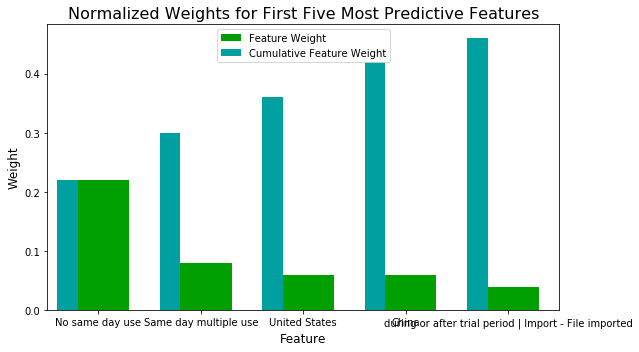

```python
feature_plot(importances, features_final, purchase_type)
```

## Analysis

In addition to the model creation I've investigated the data (focusing on the user behaviour) to see any patterns or interesting insights.

My thoughts and recommendation would be the following:

In my experience it's always good to segment the data into different buckets. Because this provides an opportunity to see if there are segments where the business is operating as we would want to, then we can check these "parts" in detail in a more micsroscopic view which could help us find sinergies with the part which not operates as we would wish to. Also what can bring a significant value to the table if we're trying to join multiple datasources (e.g.: finance - procurement, Usage date - Version control tool) and see the big picture based on the interaction of the multiple sources. To analyse the data I've created the following flags:

### use_flag_before_trial :

Has the user used the application in any way or form before the trial.

### used_amount_before_trial :

Has the user used the application more before or during the trial version? This can provide a good direction to understand if the value proposition of the pro features are providing enough value to the users or not.

### learning_habits:

This flag is to see the behaviour of the user when it comes to the tutorial videos. Have they checked out more before or after trial.

### daily_use_flag:

Since it seems to be an important factor if the user used the app multiple times over one day I wanted to check the number of these events before and during the trial:

So from the charts it's clear that the heavy users are located in China and in the US. I'm assuming that the company would want to increase global coverage with the app, but this could be important for the product owners and marketing personel to have a separate look for these regions.

Based on the flags I've created I would propose to take a deeper look in the following user segments (asking more feedback (survey, mails, etc), or check if we can see more data about their usage on a more granular level):

1. 46% of the total users have used the app already before staring the trial, also this piece is 66% of the users whom not converted at the end of the trial period. This numbers are probably rational due to the "internet mindset" of today's users, meaning that for some stuff (e.g. podcasts) the users just expects to be free, because there are so many "free" content available on the net. However this user segment could be interesting to : a, reach out to them in any way (survey, mails, etc) b, investigate their usage on a more granular level . Because this segment probably was not happy enough with the value proposition of the pro features. I think the fundamental questions is : Can the development team bring such features to live in that this segment is decreases continuously, also what are these features and how can we prioratize them. It would be interesting to join in the version control data to see what features in the pipeline and what could potentially effect this piece.

(Please see first sunburst chart (clickable)

1. 22% of the total number of users have used multiple times daily during the trial , and whom did not subscribe at the end. This bucket is also 34% of the users whom did not subscribe, also we can say about this segment that they've used the product more during the trial period than before. This segment could provide meaningful feedback about what they were missing because if we think about it. They've used it more than the free version, also they've used it several times within one day, but still skipped the subscription. Even if they can't tell what they were missing a more detailed check on their telemetry data could provide some actions to the development team.

(Please see second sunburst chart (clickable)

1. Last but not least, in the final chart we can see that the big chunk of the users who did not subscribe, never watched any tutorial video about the product. I would investigate it in a more detailed manner if there are any gaps between the usage of the learning materials and a more detailed usage data. There are probably patterns for "rage quits" in the data. We could check a few sample of these cases and see if learning material is available for these cases or not. If the use is more convenient for this segment, possibly they would convert to the subscription model more easily.

(Please see third sunburst chart (clickable)

These are only just a few points that stood out for me but in general I would propose the following:

1. Identify high impact segments from these buckets or even create more flags to the business requirements
2. Join in information related to the development funnel to see what is in the pipeline and try to find the features-epics for the organization which will have the most impact on these identified segments.

```python
country_agg = (user_data[['Country', 'value']]
               .groupby('Country')
               .sum()
               .reset_index()
               .sort_values('value', ascending=False))
fig = px.bar(country_agg, x='Country', y='value', title = 'Number of events by country')
fig.show()
```

[interactive chart not shown]

```python
#creating new dataframe to analyse user patterns
user_need = user_base[user_base.columns[0:13]]
user_need = pd.merge(user_need, user_base[['UserId', 'PurchaseType']], on='UserId', how='left')
user_need['user_count'] = 1
user_need.reset_index(inplace=True,drop=True)
```

```python
user_need[['PurchaseType', 'user_count']].groupby('PurchaseType').sum().reset_index()
```

|  | PurchaseType | user_count |
| --- | --- | --- |
| 0 | No Trial conversion | 7894 |
| 1 | Trial conversion | 4068 |

```python
user_need.columns
```

```
Index(['UserId', 'before trial | App - Launch', 'before trial | Export - Save as - File Exported', 'before trial | Import - File imported', 'before trial | Learn - Post onboarding video watched', 'before trial | Onboarding - Finished', 'during or after trial period | App - Launch', 'during or after …
```

```python
#Creating new columns to see the number of concecutive (same day events)
#happening before the user started the trial and during the trial

daily_use_trial = app_launches.pivot_table('value', 'UserId', columns=['before_after_flag', 'same_day_use_flag'], aggfunc='sum')

before = daily_use_trial['before trial period'].copy()
before.reset_index(inplace=True)
before.columns = ['before trial | ' + x for x in before.columns]
before.rename(columns={'before trial | UserId' : 'UserId'}, inplace=True)

user_need = pd.merge(user_need, before, on='UserId', how='left')

after = daily_use_trial['during or after trial period'].copy()
after.reset_index(inplace=True)
after.columns = ['during or after trial period | ' + x for x in after.columns]
after.rename(columns={'during or after trial period | UserId' : 'UserId'}, inplace=True)

user_need = pd.merge(user_need, after, on='UserId', how='left')

user_need.fillna(0, inplace=True)
```

```python
#generating flags
user_need['use_flag_before_trial'] = user_need.apply(create_usage_flags,  calc_type='flag_01', axis=1)
user_need['used_amount_before_trial'] = user_need.apply(create_usage_flags,  calc_type='flag_02', axis=1)
user_need['learning_habits'] = user_need.apply(create_usage_flags,  calc_type='flag_03', axis=1)
user_need['daily_use_flag'] = user_need.apply(create_usage_flags,  calc_type='flag_04', axis=1)
```

```python
fig = px.sunburst(user_need, path=[ 'PurchaseType', 'use_flag_before_trial'], values='user_count', width=1000, height=1000)
fig.update_traces( textinfo='label+percent entry')
fig.show()
```

[interactive chart not shown]

```python
fig = px.sunburst(user_need, path=[ 'PurchaseType', 'used_amount_before_trial', 'daily_use_flag'], values='user_count',
                  width=1000, height=1000)
fig.update_traces( textinfo='label+percent entry')
fig.show()
```

[interactive chart not shown]

```python
fig = px.sunburst(user_need, path=[ 'PurchaseType', 'learning_habits'], values='user_count', width=1000, height=1000)
fig.update_traces( textinfo='label+percent entry')
fig.show()
```

[interactive chart not shown]